# R-SQL-dplyr

Dana Kozáková

2025-04-29

# Knižnica `dplyr` + tidy princíp pre big data

- **práca s big data**: dáta sa nenačítajú celé do pamäti. Namiesto toho dplyr generuje SQL dotazy, ktoré sa spúšťajú priamo na serveri
- **nezávislosť na zdroji dát**: rovnaká syntax ako pre dataframe, či iné zdroje
- **podpora balíčkov**: využíva `DBI` a `obdc` pre pripojenie k DB
- **integrácia s vizualizáciami**: vyborne spolupracuje s ggplot2 a ďalšími `tidyverse` knižnicami

```r
suppressWarnings({
library(odbc)
library(DBI)
library(dplyr)
library(ggplot2)
})
```

```r
con <- dbConnect(odbc(), Driver = "***",
                 Server = "***", Database = "***",
                 Trusted_Connection = "yes",
                 encoding = "CP1250")
```

# Zadanie

- Načítajte dáta z tabuľky `nákaza` pomocou knižnice `dplyr`. Zobrazte dotaz, ktorý používa knižnica `dplyr`.
- Vypíšte celkový počet novonakazených pre jednotlivé dni v dátach. Dáta zoraďte. Výsledok vykreslite v grafe.
- Pridajte do grafu krivku vyhladenia.
- Načítajte dáta z tabuľky `okres`. Vypíšte celkový počet novonakazených pre jednotlivé dni v okrese Praha. Dáta zoraďte a zobrazte v grafe.
- Aký bol maximálny počet novonakazených za deň v sledovanom období v Prahe?
- Vykreslite histogram pre počet novonakazených za deň v Prahe (Zjednodušenie: neuvažujte dni, keď nebol žiaden novonakazený)
- Načítajte dáta z tabuľky `kraj`. Zobrazte graf podľa počtu obcí v okrese jednotlivých krajov. Okresy vhodne rozdeľte do 3 kategórií podľa počtu obcí
- Nakreslite boxplot pre počet novonakazených za deň v Juhomoravskom kraji po okresoch

# Riešenie:

## Tidy princíp pre big data

- Načítajte dáta z tabuľky `nákaza` pomocou knižnice `dplyr`. Tabuľka má viac ako 3 mil. riadkov.

```r
dataTable <- dbReadTable(con, "nakaza") #

data<-tbl(con, "nakaza") #príkaz tbl vytvoří pouze odkaz na data # v data je teraz tabulka nakaza
```

- prikaz `dbReadTable` načíta celé dáta do pamäti R
- príkaz `tbl` vytvorí len odkaz na dáta v tabuľke

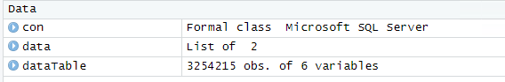

```r
dataTable |> class()
```

```
## [1] "data.frame"
```

```r
data |> class()
```

```
## [1] "tbl_Microsoft SQL Server" "tbl_dbi"
## [3] "tbl_sql"                  "tbl_lazy"
## [5] "tbl"
```

- Zobrazte dotaz, ktorý používa knižnica `dplyr`.

```r
data |> show_query()
```

```
## <SQL>
## SELECT *
## FROM "nakaza"
```

## Príkazy v `dplyr`

**Ekvivalenty SQL príkazov v kniznici `dplyr`**

- `select` – SELECT (bez možnosti vypočítavaných stĺpcov)
- `mutate` – vypočítaný stlpec v SELECTe
- `filter` – WHERE
- `summarise` - agregačné funkcie
- `group_by` – GROUP BY
- `arrange` – ORDER BY
- `inner_join` – ekvivalent JOIN

Vybrať len stĺpec nak_datum_hlaseni, zobraziť SQL príkaz

```r
data |> select(nak_datum_hlaseni) |> print(5)
```

```
## # Source:   SQL [?? x 1]
## # Database: Microsoft SQL Server 15.00.2000[MATH\xkozakovad@REX\SQLEXPRESS/VYUKA_DATABAZE]
##    nak_datum_hlaseni
##    <date>
##  1 2020-03-01
##  2 2020-03-01
##  3 2020-03-01
##  4 2020-03-03
##  5 2020-03-03
##  6 2020-03-04
##  7 2020-03-05
##  8 2020-03-05
##  9 2020-03-05
## 10 2020-03-06
## # i more rows
```

```r
data |> select(nak_datum_hlaseni) |> show_query()
```

```
## <SQL>
## SELECT "nak_datum_hlaseni"
## FROM "nakaza"
```

```r
data |> select(nak_datum_hlaseni) |> class()
```

```
## [1] "tbl_Microsoft SQL Server" "tbl_dbi"
## [3] "tbl_sql"                  "tbl_lazy"
## [5] "tbl"
```

- vyberie len stlpec nak_datum_hlaseni, je to tiez typu tbl

Tbl možno konvertovať na dataframe, tým sa to načíta do pamäte R

```r
df <- data |> select(nak_datum_hlaseni) |> as.data.frame()
```

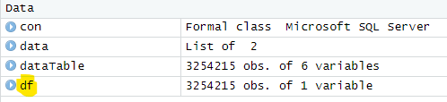

Vypočítať nový stĺpec (priamo v selecte to nie je možné)

- rok dátumu hlásenia

```r
data |> mutate(rok=year(nak_datum_hlaseni)) |> print(n = 5)
```

```
## # Source:   SQL [?? x 7]
## # Database: Microsoft SQL Server 15.00.2000[MATH\xkozakovad@REX\SQLEXPRESS/VYUKA_DATABAZE]
##   nak_id nak_datum_hlaseni nak_vek nak_pohlavi ok_kod typ_hlaseni   rok
##    <int> <date>              <int> <chr>        <int> <chr>       <int>
## 1      1 2020-03-01             67 M               50 N            2020
## 2      2 2020-03-01             43 M               11 N            2020
## 3      3 2020-03-01             21 Z               50 N            2020
## 4      4 2020-03-03             21 Z               50 N            2020
## 5      5 2020-03-03             53 Z               11 N            2020
## # i more rows
```

```r
data |> mutate(rok = year(nak_datum_hlaseni)) |> show_query()
```

```
## <SQL>
## SELECT "nakaza".*, DATEPART(YEAR, "nak_datum_hlaseni") AS "rok"
## FROM "nakaza"
```

Vyfiltrovať len novonakazených

```r
data |> filter(typ_hlaseni=='N') |> print(n = 5)
```

```
## # Source:   SQL [?? x 6]
## # Database: Microsoft SQL Server 15.00.2000[MATH\xkozakovad@REX\SQLEXPRESS/VYUKA_DATABAZE]
##   nak_id nak_datum_hlaseni nak_vek nak_pohlavi ok_kod typ_hlaseni
##    <int> <date>              <int> <chr>        <int> <chr>
## 1      1 2020-03-01             67 M               50 N
## 2      2 2020-03-01             43 M               11 N
## 3      3 2020-03-01             21 Z               50 N
## 4      4 2020-03-03             21 Z               50 N
## 5      5 2020-03-03             53 Z               11 N
## # i more rows
```

```r
data |> filter(typ_hlaseni=='N') |> show_query()
```

```
## <SQL>
## SELECT "nakaza".*
## FROM "nakaza"
## WHERE ("typ_hlaseni" = 'N')
```

## Počet nakazených za dni - graf

- Vypíšte celkový počet novonakazených pre jednotlivé dni v dátach. Dáta zoraďte.

```r
data_N <- data |>
  group_by(nak_datum_hlaseni) |>
  filter(typ_hlaseni=='N') |> # analogia "where" z SQL
  summarise(pocet=count(nak_datum_hlaseni)) |>
  arrange(nak_datum_hlaseni) # analogia "order by" z SQL

data_N |> head(5)
```

```
## # Source:     SQL [?? x 2]
## # Database:   Microsoft SQL Server 15.00.2000[MATH\xkozakovad@REX\SQLEXPRESS/VYUKA_DATABAZE]
## # Ordered by: nak_datum_hlaseni
##   nak_datum_hlaseni pocet
##   <date>            <int>
## 1 2020-03-01            3
## 2 2020-03-03            2
## 3 2020-03-04            1
## 4 2020-03-05            3
## 5 2020-03-06           11
```

```r
data_N |> show_query()
```

```
## <SQL>
## SELECT "nak_datum_hlaseni", count("nak_datum_hlaseni") AS "pocet"
## FROM (
##   SELECT "nakaza".*
##   FROM "nakaza"
##   WHERE ("typ_hlaseni" = 'N')
## ) "q01"
## GROUP BY "nak_datum_hlaseni"
## ORDER BY "nak_datum_hlaseni"
```

(!) logicky by mal byt `group_by` az za `filter`, ale tu na poradi prikazov nezalezi, SQL dotaz je rovnaky

- Výsledok vykreslite v grafe.

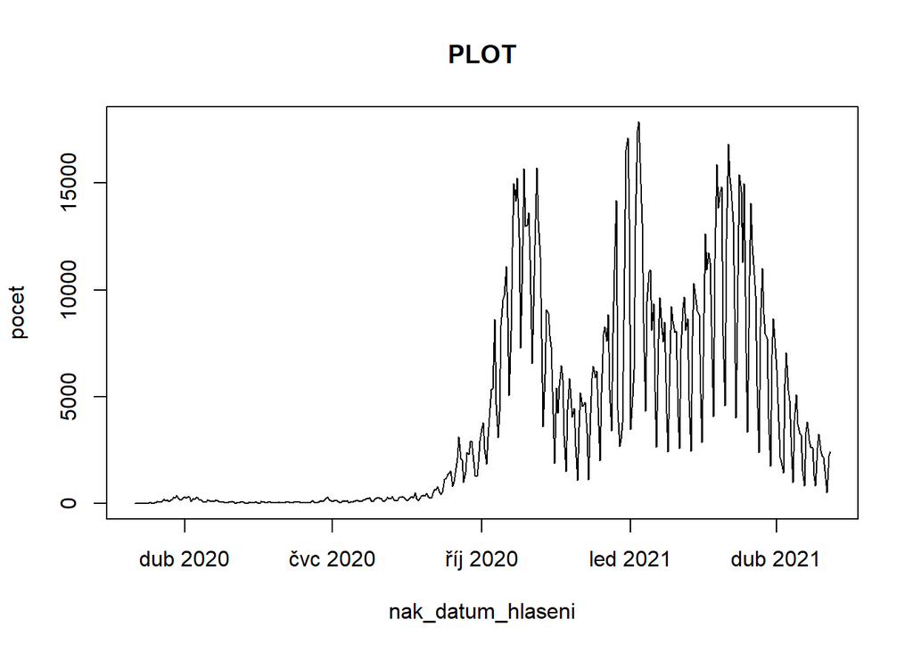

```r
data_N %>% plot(pocet ~ nak_datum_hlaseni, data = .,type='l', main="PLOT")
```

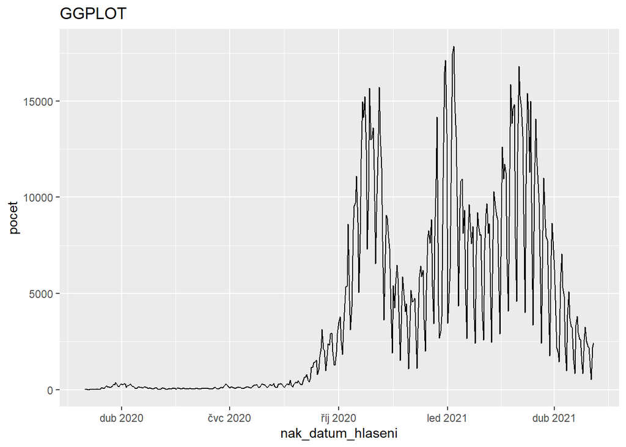

```r
data_N %>% ggplot(data = .) +
  geom_line(aes(x=nak_datum_hlaseni , y = pocet))+
  labs(title = "GGPLOT")
```

- Pridajte do grafu krivku vyhladenia.

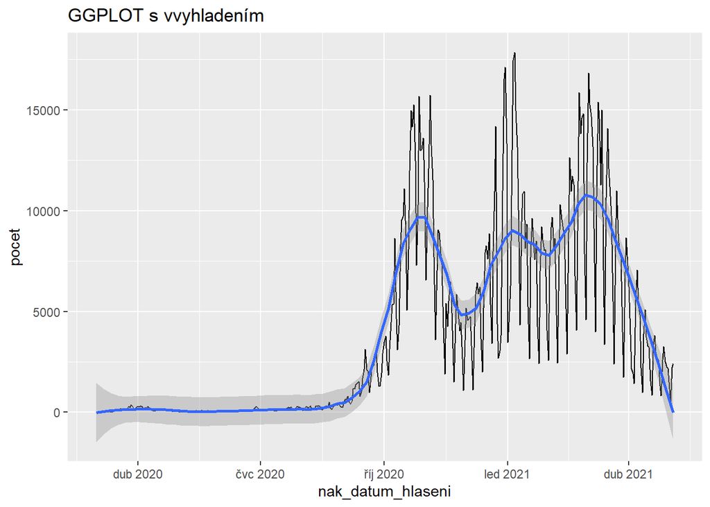

```r
data_N %>%  ggplot(data = .) +
  geom_line(aes(x=nak_datum_hlaseni , y = pocet)) +
  geom_smooth(aes(x=nak_datum_hlaseni , y = pocet),span = 0.25) +
  labs(title = "GGPLOT s vvyhladením")
```

## Prepojenie na okresy

- Načítajte dáta z tabuľky `okres`. Prepojte s tabuľkou nákaz.

Prepojiť tabuľku `okres` cez `inner_join` s tabuľkou nákaz `data`.

(!) Pri joinovaní dvoch tabuliek je defaultne nastavené, že to prepojí cez rovnako nazvané stĺpce. Pre tieto tabuľky je to `ok_kod`.

```r
okres<-tbl(con, "okres")

data |> colnames()
```

```
## [1] "nak_id"            "nak_datum_hlaseni" "nak_vek"
## [4] "nak_pohlavi"       "ok_kod"            "typ_hlaseni"
```

```r
okres |> colnames()
```

```
## [1] "ok_kod"          "ok_nazev_kratky" "ok_nazev_dlouhy" "ok_cznuts"
## [5] "ok_rozloha"      "ok_pocet_obci"   "kr_kod"
```

```r
inner_join(data,okres ) |> head(5)
```

```
## # Source:   SQL [?? x 12]
## # Database: Microsoft SQL Server 15.00.2000[MATH\xkozakovad@REX\SQLEXPRESS/VYUKA_DATABAZE]
##   nak_id nak_datum_hlaseni nak_vek nak_pohlavi ok_kod typ_hlaseni
##    <int> <date>              <int> <chr>        <int> <chr>
## 1      1 2020-03-01             67 M               50 N
## 2      2 2020-03-01             43 M               11 N
## 3      3 2020-03-01             21 Z               50 N
## 4      4 2020-03-03             21 Z               50 N
## 5      5 2020-03-03             53 Z               11 N
## # i 6 more variables: ok_nazev_kratky <chr>, ok_nazev_dlouhy <chr>,
## #   ok_cznuts <chr>, ok_rozloha <dbl>, ok_pocet_obci <int>, kr_kod <int>
```

- Vypíšte celkový počet novonakazených pre jednotlivé dni v okrese Praha.

```r
nakaza_praha<-inner_join(data,okres, by = join_by(ok_kod)) |>
  group_by(nak_datum_hlaseni) |>
  filter(typ_hlaseni=='N', ok_nazev_kratky=='Praha') |>
  summarise(pocet = count(nak_datum_hlaseni))

nakaza_praha |> head(5)
```

```
## # Source:   SQL [?? x 2]
## # Database: Microsoft SQL Server 15.00.2000[MATH\xkozakovad@REX\SQLEXPRESS/VYUKA_DATABAZE]
##   nak_datum_hlaseni pocet
##   <date>            <int>
## 1 2020-07-29           71
## 2 2021-04-16          338
## 3 2020-07-06            9
## 4 2020-09-13          263
## 5 2020-08-21          143
```

Oproti predchádzajúcemu kódu (bez filtrovania okresu) je tu rozdiel:

- vstupom je inner_join
- pre filter je aj podmienka pre Prahu
- Dáta zoraďte a zobrazte v grafe.

```r
print("Maximálny počet nakazených: ")
```

```
## [1] "Maximálny počet nakazených: "
```

```r
nakaza_praha |>
  summarize(Max = max(pocet, na.rm=TRUE))
```

```
## # Source:   SQL [?? x 1]
## # Database: Microsoft SQL Server 15.00.2000[MATH\xkozakovad@REX\SQLEXPRESS/VYUKA_DATABAZE]
##     Max
##   <int>
## 1  2069
```

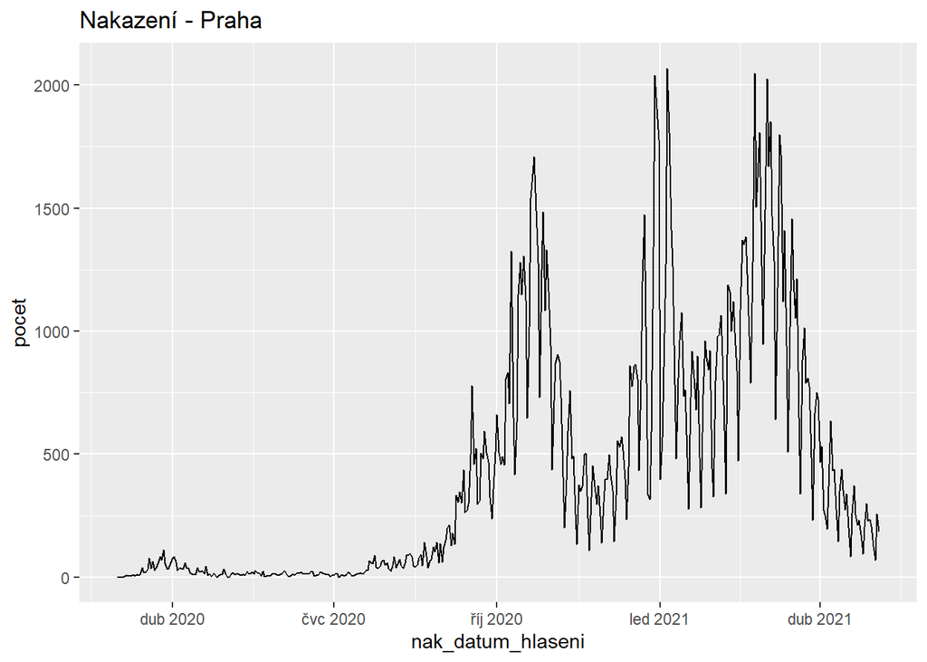

```r
nakaza_praha %>%
  arrange(nak_datum_hlaseni) %>%
  ggplot(data = .) +
    geom_line(aes(x=nak_datum_hlaseni , y = pocet)) +
    labs(title = "Nakazení - Praha")
```

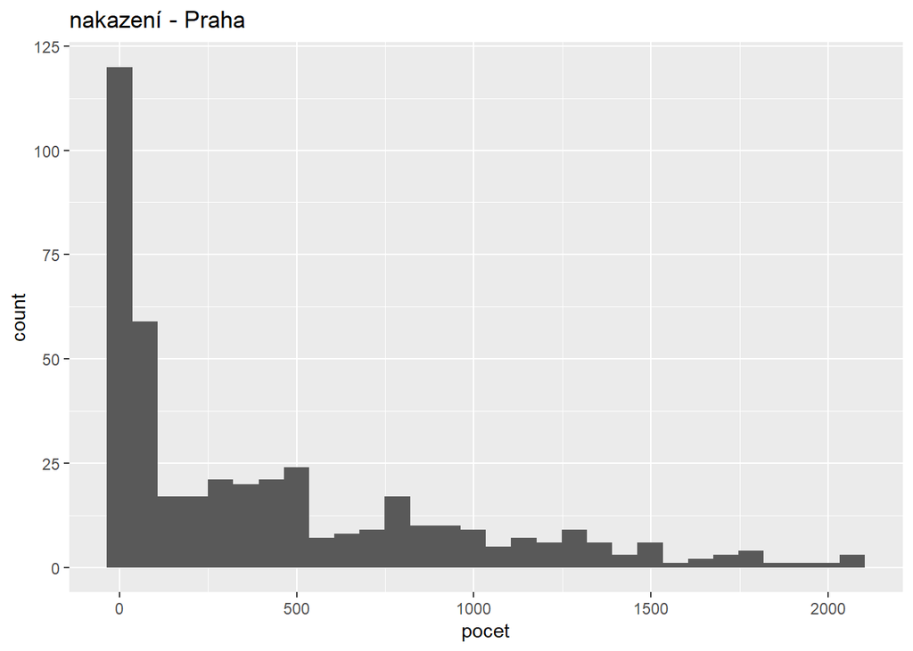

```r
nakaza_praha %>%
  ggplot(data = .) +
  geom_histogram(aes(x = pocet)) +
  labs(title = "nakazení - Praha")
```

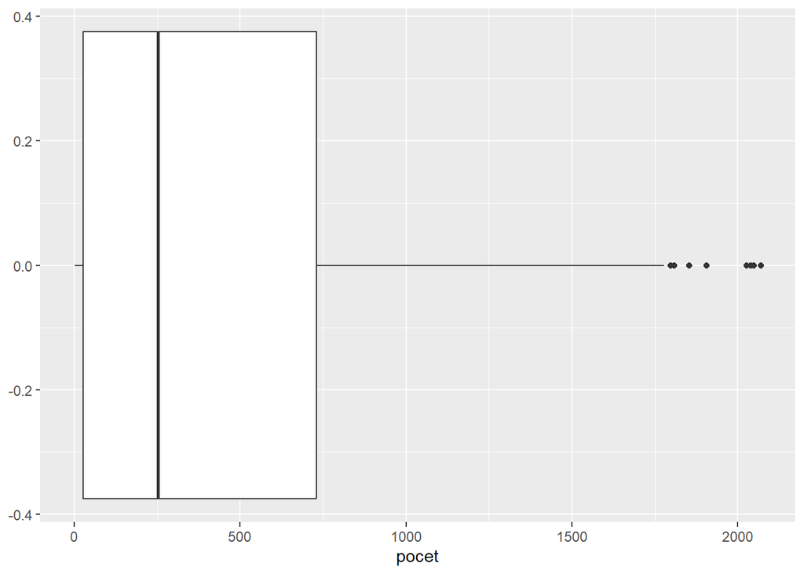

```r
nakaza_praha %>%
  ggplot(data = .) +
  geom_boxplot(aes(x = pocet))
```

**Hodnoty boxplotu:**

- ak chceme aj vypísať hodnoty, ktoré sú použité pre boxplot: kvartily, medián, outlieri, atď, Ak chceme extrahovať tieto údaje –> funkcia `ggplot_build()`:

```r
b<-nakaza_praha %>%
  ggplot(data = .) + geom_boxplot(aes(x = pocet))

ggplot_build(b)$data
```

```
## [[1]]
##   xmin xlower xmiddle xupper xmax
## 1    1   26.5     252  730.5 1778
##                                               outliers notchupper notchlower y
## 1 2048, 1853, 1808, 1808, 2026, 2040, 2069, 1905, 1798   305.8289   198.1711 0
##   flipped_aes PANEL group xmin_final xmax_final   ymin  ymax xid newx new_width
## 1        TRUE     1    -1          1       2069 -0.375 0.375   1    0      0.75
##   weight colour  fill alpha shape linetype linewidth
## 1      1 grey20 white    NA    19    solid       0.5
```